# Lab 5

# 8H5

Consider the data data table. These data are expert ratings of 20 different French and American wines by 9 different French and American judges. Your goal is to model score, the subjective rating assigned by each judge to each wine. I recommend standardizing it. In this problem, consider only variation among judges and wines. Construct index variables of judge and wine and then use these index variables to construct a linear regression model. Justify your priors. You should end up with 9 judge parameters and 20 wine parameters. How do you interpret the variation among individual judges and individual wines? Do you notice any patterns, just by plotting the differences? Which judges gave the highest/lowest ratings? Which wines were rated worst/best on average?

## Load packages

```r
library(rethinking)
library(rjags)
```

We can first view the dataset:

```r
data(Wines2012)
View(Wines2012)
d <- Wines2012
```

We can consider building the following model:

Since we only consider only variation among judges and wines, we group the scores by judges and the different wines:

$$\begin{align*}
s_i &\sim N(\mu_i, \sigma^2) \\
\mu_i &= \alpha_{\text{JID}[i]} + w_{\text{WID}[i]} \\
\alpha_{\text{JID}[i]} &\sim N(0,0.5^2) \\
\beta_{\text{WID}[i]} &\sim N(0,0.5^2) \\
\sigma & \sim \text{Exp}(1)
\end{align*}$$

Couple of things to notice:

- standardize the continuous observation $s$ before fitting the data to the model
- choosing priors for $\alpha$, $\beta$: after standardizing $s$ has mean 0, standard deviation 1, which is roughly approximated as $N(0,1)$. For two independent effects $\alpha$, $\beta$, if we place a normal prior $N(0,0.5)$ on these effects, there sum will be $N(0,1)$, which covers the bulk of our data

```r
dat_list <- list(
    S = standardize(d$score), # standardize the data
    jid = as.integer(d$judge), # group by judge
    wid = as.integer(d$wine) # group by wine
)
# have a look at the ids
str(dat_list)
```

Fit the model:

```r
m1 <- quap(
    alist(
      # likelihood: score distributed as normal, mean is mu, std is sigma
        S ~ dnorm( mu , sigma ),
      # mean function: mean broken into two groups, judge effect(a) and wine effect(w)
      # indexed by their ids
        mu <- a[jid] + w[wid],
      # priors
        a[jid] ~ dnorm(0,0.5),
        w[wid] ~ dnorm(0,0.5),
        sigma ~ dexp(1)
    ),
    # data
    data=dat_list)
plot( precis( m1 , 2 ) )
```

### STAN implementation

```r
library(rstan)
model_code <- "
  data{
    // data
    int<lower=1> N; // number of observations
    vector[N] S; // obsrevations

    // grouping factors
    int<lower=1> Jid; // number of judge ids
    int<lower=1, upper=Jid> jid[N]; // judge ids
    int<lower=1> Wid; // number of judge ids
    int<lower=1, upper=Wid> wid[N]; // judge ids

    // hyperparameters: feed in the values
    real ma;
    real mb;
    real sa;
    real sb;
    real lambda;
  }
  // important! for parameters you want to set their ranges
  parameters{
    vector[Jid] a; // judge effect
    vector[Wid] b; // wine effect
    real<lower=0> sigma;
  }
  model{
    // declare variable for the expected outcome
    // important! mu is a local variable
    // in stan we need to put mu in the model, instead of the parameter
    vector[N] mu;
    // priors
    a ~ normal(ma, sa);
    b ~ normal(mb, sb);
    sigma ~ exponential(lambda);
    // likelihood
    for (i in 1:N) {
      mu[i] = a[jid[i]] + b[wid[i]];
    }
    S ~ normal(mu, sigma);
  }
"
stan.out <- stan(
  model_code = model_code,
  iter = 1e4, # length of the markov chain
  data = list(
    N = length(dat_list$S),
    S = dat_list$S,
    Jid = max(dat_list$jid),
    jid = dat_list$jid,
    Wid = max(dat_list$wid),
    wid = dat_list$wid,
    ma = 0,
    sa = 0.5,
    mb = 0,
    sb = 0.5,
    lambda = 1
  )
)
print(stan.out)
stan_plot(stan.out, pars = c("a", "b"))
```

### JAGS implementation

```r
m1_code <- "
  # the data object we read in will also be here
  data {
    D <- dim(S)
    n <- D[1]
  }
  model{
  # in JAGS we tend to specify everything iteratively
   for(i in 1:n){
      # likelihood
      S[i] ~ dnorm(mu[i], tau)
      # bracket notation
      mu[i] = a[jid[i]] + b[wid[i]]
      # posterior predictive
      # ynew[i] ~ dnorm(mu[i], tau)
   }
    # conditional mean using matrix algebra
    # beware of the precision specification
    for (j in 1:Jid) {
      a[j] ~ dnorm(ma, pow(sa, -2))
    }
    for (j in 1:Wid) {
      b[j] ~ dnorm(mb, pow(sb, -2))
    }
    sigma ~ dexp(lambda)
    tau <- pow(sigma, -2)
  }
"
m8.5.jags <- jags.model(
  file = textConnection(m1_code),
  data = list(
    S = dat_list$S,
    jid = dat_list$jid,
    wid = dat_list$wid,
    Jid = max(dat_list$jid),
    Wid = max(dat_list$wid),
    ma = 0,
    sa = 0.5,
    mb = 0,
    sb = 0.5,
    lambda = 1
  )
)
```

### view results

```r
m8.5.samps <- coda.samples(m8.5.jags,
                           variable.names = c("a", "b"),
                           n.iter = 1e4)
m8.5.samps.df <- as.data.frame(m8.5.samps[[1]])
plot(precis(m8.5.samps.df, depth = 2))
```

### interpret the data

How do you interpret the variation among individual judges and individual wines? Do you notice any patterns, just by plotting the differences? Which judges gave the highest/lowest ratings? Which wines were rated worst/best on average?

- Judges with lower values are harsher on average. Judges with higher values liked the wines more on average
- Wines with lower values are generally given lower scores and vice versa
- Overall, there is more variation from judge than from wine

## Model Matrix

$$\begin{align*}
\mathbf{X_{\alpha}}_{i,j} = 1, \text{ if the i-th score is given by judge $j$, o.w.$ \mathbf{X_{\alpha}}_{i,j} = 0$}
\end{align*}$$

The same goes for $\mathbf{X_{\beta}}$.

We thus preprocess the dataset to get the model matrix we want:

```r
 model.matrix(~  judge + (wine-1),
                  data = dat_x)
```

```
    judgeDaniele Meulder judgeFrancis Schott judgeJamal Rayyis judgeJean-M Cardebat judgeJohn Foy
1                      0                   0                 0                    1             0
2                      0                   0                 0                    1             0
3                      0                   0                 0                    1             0
4                      0                   0                 0                    1             0
5                      0                   0                 0                    1             0
6                      0                   0                 0                    1             0
7                      0                   0                 0                    1             0
8                      0                   0                 0                    1             0
9                      0                   0                 0                    1             0
10                     0                   0                 0                    1             0
11                     0                   0                 0                    0             0
12                     0                   0                 0                    0             0
13                     0                   0                 0                    0             0
14                     0                   0                 0                    0             0
```

[output cut: 102 more lines]

[figure not shown]

```r
m1_code <- "
  data {
    D <- dim(S)
    n <- D[1]
  }
  model{

   for(i in 1:n){
      # likelihood
      S[i] ~ dnorm(mu[i], tau)

      # posterior predictive
      # ynew[i] ~ dnorm(mu[i], tau)
   }
   mu = x1%*%a + x2%*%b
   # conditional mean using matrix algebra
   for (j in 1:Jid) {
     a[j] ~ dnorm(ma, pow(sa, -2))
   }
   for (j in 1:Wid) {
     b[j] ~ dnorm(mb, pow(sb, -2))
   }
   sigma ~ dexp(lambda)
   tau <- pow(sigma, -2)
}
"
m8.5.jags <- jags.model(file = textConnection(m1_code),
                        data = list(S = dat_list$S,
                                    Jid = max(dat_list$jid),
                                    Wid = max(dat_list$wid),
                                    x1 = x1,
                                    x2 = x2,
                                    ma = 0,
                                    sa = 0.5,
                                    mb = 0,
                                    sb = 0.5,
                                    lambda = 1))
```

[output not shown]

```r
m8.5.samps <- coda.samples(m8.5.jags, variable.names = c("a", "b"),
                           n.iter = 1e4)
```

[output not shown]

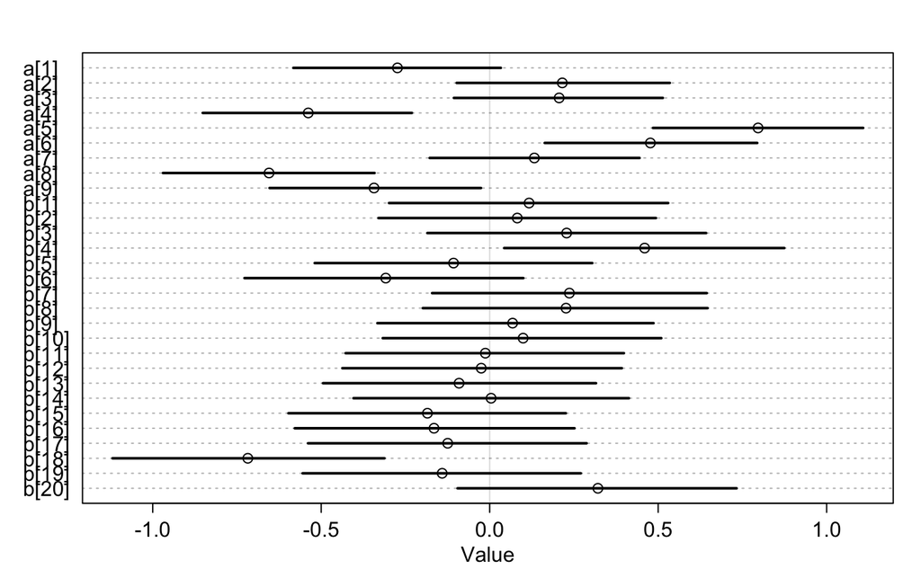

```r
m8.5.samps.df <- as.data.frame(m8.5.samps[[1]])
plot(precis(m8.5.samps.df, depth = 2))
```

```r
library(rstan)
model_code <- "
  data{
    // data
    int<lower=1> N; // number of observations
    real S[N]; // obsrevations

    // matrices corresponding to grouping factors
    int<lower=1> Jid; // number of judge ids
    int<lower=1> Wid; // number of wine ids
    matrix[N,Jid] x1; // model matrix for judge
    matrix[N,Wid] x2; // model matrix for wine

    // hyperparameters
    real ma;
    real mb;
    real sa;
    real sb;
    real lambda;
  }
  parameters{
    vector[Jid] a; // judge effect
    vector[Wid] b; // wine effect
    real<lower=0> sigma;
  }
  model{
    real mu[N];
    // priors
    a ~ normal(ma, sa);
    b ~ normal(mb, sb);
    sigma ~ exponential(lambda);
    // likelihood
    S ~ normal(x1*a + x2*b, sigma);
  }
"
stan.out <- stan(model_code = model_code, iter = 1e4,
                 data = list(N = length(dat_list$S),
                             S = dat_list$S,
                             x1 = x1,
                             x2 = x2,
                             Jid = max(dat_list$jid),
                             Wid = max(dat_list$wid),
                             ma = 0,sa = 0.5,
                             mb = 0,sb = 0.5,lambda = 1))
```

[output not shown]

[output not shown]

[output cut: 219 more lines]

[output not shown]

```r
print(stan.out)
```

```
Inference for Stan model: rt_cmdstanr_2456b3f3f41a852e9023a75dc342d4ee-202204281059-1-57699d.
1 chains, each with iter=10000; warmup=5000; thin=1;
post-warmup draws per chain=5000, total post-warmup draws=5000.

        mean se_mean   sd   2.5%    25%    50%    75%  97.5% n_eff Rhat
a[1]   -0.28     0.0 0.19  -0.66  -0.41  -0.28  -0.15   0.10  5740    1
a[2]    0.22     0.0 0.20  -0.17   0.08   0.21   0.35   0.60  5954    1
a[3]    0.21     0.0 0.19  -0.17   0.08   0.21   0.34   0.59  6176    1
a[4]   -0.54     0.0 0.19  -0.90  -0.67  -0.54  -0.41  -0.16  5298    1
a[5]    0.80     0.0 0.19   0.41   0.67   0.80   0.93   1.18  6101    1
a[6]    0.48     0.0 0.19   0.10   0.35   0.47   0.61   0.86  5648    1
a[7]    0.13     0.0 0.20  -0.26  -0.01   0.13   0.26   0.51  6266    1
a[8]   -0.66     0.0 0.20  -1.04  -0.79  -0.66  -0.53  -0.27  6136    1
a[9]   -0.35     0.0 0.19  -0.72  -0.47  -0.35  -0.22   0.03  5997    1
b[1]    0.12     0.0 0.26  -0.38  -0.06   0.12   0.29   0.62  6677    1
b[2]    0.08     0.0 0.26  -0.43  -0.09   0.08   0.26   0.60  6864    1
b[3]    0.22     0.0 0.26  -0.29   0.05   0.22   0.39   0.75  7466    1
b[4]    0.46     0.0 0.25  -0.04   0.29   0.46   0.63   0.95  8162    1
b[5]   -0.10     0.0 0.26  -0.61  -0.27  -0.10   0.06   0.40  7518    1
b[6]   -0.31     0.0 0.26  -0.81  -0.48  -0.31  -0.14   0.19  8209    1
b[7]    0.24     0.0 0.25  -0.24   0.07   0.24   0.41   0.74  8003    1
b[8]    0.23     0.0 0.26  -0.28   0.06   0.23   0.40   0.73  7240    1
b[9]    0.07     0.0 0.25  -0.41  -0.10   0.07   0.24   0.55  6665    1
b[10]   0.10     0.0 0.26  -0.40  -0.07   0.10   0.28   0.62  7774    1
b[11]  -0.01     0.0 0.25  -0.50  -0.18  -0.01   0.16   0.50  7634    1
b[12]  -0.02     0.0 0.27  -0.55  -0.21  -0.03   0.16   0.50  8328    1
b[13]  -0.09     0.0 0.26  -0.58  -0.26  -0.09   0.09   0.41  7316    1
b[14]   0.01     0.0 0.26  -0.50  -0.16   0.01   0.18   0.51  7330    1
b[15]  -0.18     0.0 0.26  -0.69  -0.36  -0.18   0.00   0.33  7011    1
b[16]  -0.17     0.0 0.25  -0.67  -0.34  -0.17   0.00   0.33  7308    1
b[17]  -0.13     0.0 0.27  -0.66  -0.30  -0.13   0.05   0.40  8161    1
b[18]  -0.72     0.0 0.25  -1.21  -0.89  -0.72  -0.55  -0.22  7570    1
b[19]  -0.14     0.0 0.26  -0.63  -0.31  -0.14   0.04   0.37  8390    1
b[20]   0.32     0.0 0.25  -0.17   0.16   0.32   0.49   0.82  8384    1
sigma   0.85     0.0 0.05   0.76   0.81   0.84   0.88   0.95  6629    1
lp__  -70.36     0.1 4.11 -79.31 -72.86 -70.04 -67.44 -63.25  1683    1

Samples were drawn using NUTS(diag_e) at Thu Apr 28 10:59:13 2022.
For each parameter, n_eff is a crude measure of effective sample size,
and Rhat is the potential scale reduction factor on split chains (at
convergence, Rhat=1).
```

```
ci_level: 0.8 (80% intervals)
outer_level: 0.95 (95% intervals)
```

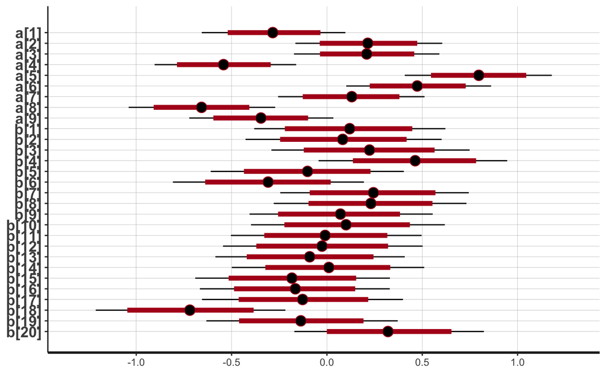

```r
stan_plot(stan.out, pars = c("a","b"))
```

# 8H6

Now consider three features of the wines and judges: - flight: Whether the wine is red or white. - wine.amer: Indicator variable for American wines. - judge.amer: Indicator variable for American judges.

Use indicator or index variables to model the influence of these features on the scores. Omit the individual judge and wine index variables from Problem 1. Do not include interaction effects yet. Again justify your priors. What do you conclude about the differences among the wines and judges? Try to relate the results to the inferences in the previous problem.

### Indicator Model

We can build the following model:

$$\begin{align*}
s_i &\sim N(\mu_i, \sigma^2) \\
\mu_i &= a + \beta_W W_{amer,i} + \beta_J J_{amer,i} + \beta_R R_i \\
a &\sim N(0,0.2^2) \\
b_W, b_J, b_R &\sim N(0,0.5^2) \\
\sigma & \sim \text{Exp}(1)
\end{align*}$$

Again, some thoughts on prior choice:

- After centering the score, it makes sense to place a tighter prior on the intercept
- Again to place priors on the b’s we can ‘think about extremes’, but a standard deviation of 0.5 is fine for here

```r
dat_list2 <- list(
    S = standardize(d$score),
    W = d$wine.amer,
    J = d$judge.amer,
    R = ifelse(d$flight=="red",1L,0L)
)
str(dat_list2)
```

```
List of 4
 $ S: num [1:180] -1.5766 -0.4505 -0.0751 0.3003 -2.3274 ...
  ..- attr(*, "scaled:center")= num 14.2
  ..- attr(*, "scaled:scale")= num 2.66
 $ W: int [1:180] 1 1 0 0 1 1 1 0 1 0 ...
 $ J: int [1:180] 0 0 0 0 0 0 0 0 0 0 ...
 $ R: int [1:180] 0 0 0 0 0 0 0 0 0 0 ...
```

```r
m2a <- quap(
    alist(
        S ~ dnorm( mu , sigma ),
        mu <- a + bW*W + bJ*J + bR*R,
        a ~ dnorm( 0 , 0.2 ),
        c(bW,bJ,bR) ~ dnorm( 0 , 0.5 ),
        sigma ~ dexp(1)
    ), data=dat_list2 )
precis( m2a )
```

[output not shown]

[figure not shown]

```r
library(rstan)
model_code <- "
  data{
    // data
    int<lower=1> N; // number of observations
    vector[N] S; // obsrevations
    vector[N] W; // wine america
    vector[N] J; // judge america
    vector[N] R; // wine color type

    // hyperparameters
    real ma;
    real mb;
    real sa;
    real sb;
    real lambda;
  }
  parameters{
    real a, bW, bJ, bR;
    real<lower=0> sigma;
  }
  model{
    real mu[N];
    // priors
    a ~ normal(ma, sa);
    bW ~ normal(mb, sb);
    bJ ~ normal(mb, sb);
    bR ~ normal(mb, sb);
    sigma ~ exponential(lambda);
    // likelihood
    S ~ normal(a + W*bW + bJ*J + bR*R, sigma);
  }
"
stan.out <- stan(model_code = model_code, iter = 1e4,
                 data = list(N = length(d$score),
                             S = standardize(d$score),
                             W = d$wine.amer,
                             J = d$judge.amer,
                             R = ifelse(d$flight=="red",1L,0L),
                             ma = 0,sa = 0.2,
                             mb = 0,sb = 0.5,lambda = 1))
print(stan.out)
stan_plot(stan.out, pars = c("a","b"))
```

### index variable version

We can build the following model (we will only provide code for quap here):

$$\begin{align*}
s_i &\sim N(\mu_i, \sigma^2) \\
\mu_i &= w_{\text{WID}[i]} + j_{\text{JID}[i]} + f_{\text{FID}[i]} \\
w_{\text{WID}[i]}, j_{\text{WID}[i]},f_{\text{WID}[i]} &\sim N(0,0.5^2) \\
\sigma & \sim \text{Exp}(1)
\end{align*}$$

```r
dat_list2b <- list(
    S = standardize(d$score),
    wid = d$wine.amer + 1L,
    jid = d$judge.amer + 1L,
    fid = ifelse(d$flight=="red",1L,2L)
)
str(dat_list2b)
m2b <- quap(
    alist(
        S ~ dnorm( mu , sigma ),
        mu <- w[wid] + j[jid] + f[fid],
        w[wid] ~ dnorm( 0 , 0.5 ),
        j[wid] ~ dnorm( 0 , 0.5 ),
        f[wid] ~ dnorm( 0 , 0.5 ),
        sigma ~ dexp(1)
    ), data=dat_list2b )
precis( m2b , 2 )
post <- extract.samples(m2b)
diff_w <- post$w[,2] - post$w[,1]
precis( diff_w )
```

## 8H7

Now consider two-way interactions among the three features. You should end up with three different interaction terms in your model. These will be easier to build, if you use indicator variables. Again justify your priors. Explain what each interaction means. Be sure to interpret the model’s predictions on the outcome scale (mu, the expected score), not on the scale of individual parameters. You can use link to help with this, or just use your knowledge of the linear model instead. What do you conclude about the features and the scores? Can you relate the results of your model(s) to the individual judge and wine inferences from 8H5?

$$\begin{align*}
s_i &\sim N(\mu_i, \sigma^2) \\
\mu_i &= a + \beta_W W_{amer,i} + \beta_J J_{amer,i} + \beta_R R_i + \beta_{WJ}W_{amer,i}J_{amer,i} +\beta_{WR}W_{amer,i}R_{amer,i} + \beta_{JR}J_{amer,i}R_{amer,i}\\
a &\sim N(0,0.2^2) \\
b_W, b_J, b_R &\sim N(0,0.5^2) \\
b_WJ, b_JR, b_WR &\sim N(0,0.25^2) \\
\sigma & \sim \text{Exp}(1)
\end{align*}$$

- a general suggestion for prior choice is to use a tighter normal prior on the interactions, we we are bringing in more parameters

```r
dat_list2 <- list(
    S = standardize(d$score),
    W = d$wine.amer,
    J = d$judge.amer,
    R = ifelse(d$flight=="red",1L,0L)
)
m3 <- quap(
    alist(
      S ~ dnorm( mu , sigma ),
    mu <- a + bW*W + bJ*J + bR*R +
          bWJ*W*J + bWR*W*R + bJR*J*R,
    a ~ dnorm(0,0.2),
    c(bW,bJ,bR) ~ dnorm(0,0.5),
    c(bWJ,bWR,bJR) ~ dnorm(0,0.25),
    sigma ~ dexp(1)
), data=dat_list2 )

pred_dat <- data.frame(
    W = rep( 0:1 , times=4 ),
    J = rep( 0:1 , each=4 ),
    R = rep( c(0,0,1,1) , times=2 )
)
mu <- link( m3 , data=pred_dat )
row_labels <- paste( ifelse(pred_dat$W==1,"A","F") ,
                 ifelse(pred_dat$J==1,"A","F") ,
                 ifelse(pred_dat$R==1,"R","W") , sep="" )
plot( precis( list(mu=mu) , 2 ) , labels=row_labels )
```

```r
m3_code <- "
  data {
    D <- dim(S)
    n <- D[1]
  }
  model{
   for(i in 1:n){
      # likelihood
      S[i] ~ dnorm(mu[i], tau)

      # posterior predictive
      # ynew[i] ~ dnorm(mu[i], tau)
   }
   mu = a + bW*W + bJ*J + bR*R + bWJ*W*J + bWR*W*R + bJR*J*R
   a ~ dnorm(0 ,pow(0.2,-2))
   bW ~ dnorm(mb, pow(sb,-2))
   bJ ~ dnorm(mb, pow(sb,-2))
   bR ~ dnorm(mb, pow(sb,-2))
   bWJ ~ dnorm(mint, pow(sint,-2))
   bWR ~ dnorm(mint, pow(sint,-2))
   bJR ~ dnorm(mint, pow(sint,-2))
   sigma ~ dexp(lambda)
   tau <- pow(sigma, -2)
}
"
m8.3.jags <- jags.model(file = textConnection(m3_code),
                        data = list(S = dat_list$S,
                                    W = d$wine.amer,
                                    J = d$judge.amer,
                                    R = ifelse(d$flight=="red",1L,0L),
                                    mb = 0,
                                    sb = 0.5,
                                    mint = 0,
                                    sint = 0.25,
                                    lambda = 1))
```

```r
library(rstan)
model_code <- "
  data{
    // data
    int<lower=1> N; // number of observations
    vector[N] S; // obsrevations
    vector[N] W; // wine america
    vector[N] J; // judge america
    vector[N] R; // wine color type
    vector[N] WJ;
    vector[N] JR;
    vector[N] WR;

    // hyperparameters
    real mint;
    real ma;
    real mb;
    real sint;
    real sa;
    real sb;
    real lambda;
  }
  parameters{
    real a, bW, bJ, bR, bWJ, bWR, bJR;
    real<lower=0> sigma;
  }
  model{
    real mu[N];
    // priors
    a ~ normal(ma, sa);
    bW ~ normal(mb, sb);
    bJ ~ normal(mb, sb);
    bR ~ normal(mb, sb);
    bWJ ~ normal(mint, sint);
    bWR ~ normal(mint, sint);
    bJR ~ normal(mint, sint);
    sigma ~ exponential(lambda);
    // likelihood
    S ~ normal(a + W*bW + bJ*J + bR*R + bWJ*WJ + bWR*WR + bJR*JR, sigma);
  }
"
stan.out <- stan(model_code = model_code, iter = 1e4,
                 data = list(N = length(d$score),
                             S = standardize(d$score),
                             W = d$wine.amer,
                             J = d$judge.amer,
                             WJ = d$wine.amer*d$judge.amer,
                             WR = d$wine.amer*ifelse(d$flight=="red",1L,0L),
                             JR = d$judge.amer*ifelse(d$flight=="red",1L,0L),
                             R = ifelse(d$flight=="red",1L,0L),
                             ma = 0,sa = 0.2,
                             mint = 0, sint = 0.5,
                             mb = 0,sb = 0.5,lambda = 1))
print(stan.out)
stan_plot(stan.out, pars = c("a","b"))
```